# Chapter 9

Yifei Liu

4/26/2019

```r
library(forecast)
library(seasonal)
library(urca)
library(readxl)
library(rdatamarket)
library(fma)
library(astsa)
library(tsibble)
library(fpp2)
library(tsibbledata) # devtools::install_github("tidyverts/tsibbledata")
library(broom)
library(tidyquant)
library(tidyverse)
library(sweep)
library(lubridate)
detach("package:dplyr", unload=TRUE)
library(dplyr)
library(tseries)
library(scales)
library(GGally)
library(fpp2)
library(fpp2)
library(timetk)
library(gridExtra)
library(ggthemes)
theme_set(theme_minimal())
```

The time series class I took, no matter how accurate they predict, such as the the ETS model I have for the US net electricity generate, even thoug the predictive value accurate predicted the number for freaking 15 yeras!!!. I still find this two model I previous used, ETS and ARIMA model have lack some important component.

These two model incorporate the information from the past observations of a series, but not for the inclusion of other information that may also be relevant, or can think about electricity usage from a long term, when new energy usage appear such as air conditioner, the movie ticket sales when deal with emerging of streaming service, the revenue of traditional cable tv company face netflix and chill :). On the other hand regression model abble to inclusion of a lot of relevant information from predictor variables, but do not allow for the subtle time series dynamic that can handled with ARIMA models.

simple linear regression model: $y_t = \beta_0 + \beta_1x_{1,t} + ... + \beta_kx_{k,t} + \epsilon_t$

where $y_t$ is a linear function of the k predictor variables and $\epsilon_t$ is usually assumed to be an uncorrelated error time.

In this chapter, we will allow the errors from a regression model to contain autocorrelation. if $\eta_t$ follow an ARIMA(1,1,1) model, we can write

$y_t = \beta_0 + \beta_1x_{1,t} + ... + \beta_kx_{k,t} + \eta_t$ $(1-\phi_1B)(1-B)\eta_t = (1+\theta_1B)\epsilon_t$

In summary, we incorporate time series model into regression error term. Which mean the error term from a time series regression model is not white noise and only ARIMA model errors are assumed to be white noise. 9.1 Estimation

Potential problem rising when use minimise the sume of squared $\eta_t$ values. (see problems on the book)

Instead we can minimising the sum of squared $\epsilon_t$ values to avouds these problems. (PS: if we need to fit time series regression model we may face multiple issues such as are we achieve global mim $\epsilon_t$ value of just a local one), alternatively, maximum likeihood estiamtion can be used. This will give similar estiamte of the coefficients.

We need to make sure the predicators and $y_t$ to be stationary, this step is essentail to make sure the coefficient will be consistent estiamted. One exception to this is the caese of non-stationary $y_t$ and the predictros that is stationary, then the estiamted coefficient will be consistent.

## 9.2 Regression with ARIMA errors in R

$fit = Arima(y, xreg = x, order = c(1,1,0))$ will fit the model $y_t' = \beta_1x_t' + \eta_t'$, where $\eta_t' = \phi_1\eta_{t-1}' + \epsilon_t$ is an AR(1) error. this is equivalent to the model $y_t = \beta_0 + \beta_1x_t + \eta_t$

### Example: US personal consumption and Income

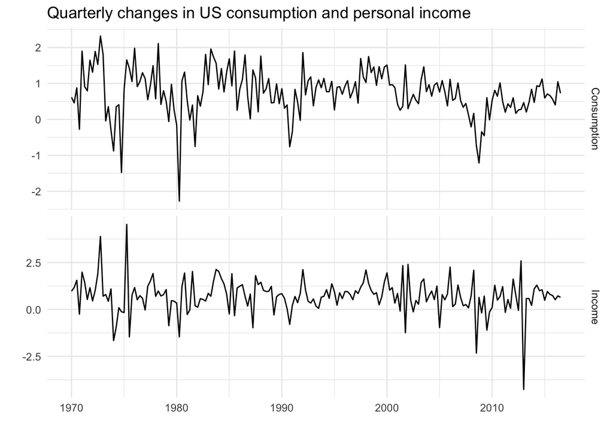

```r
autoplot(uschange[, 1:2], facets = TRUE) +
  labs(title = "Quarterly changes in US consumption and personal income",
       x = "",  y = "")
```

```r
(fit <- auto.arima(uschange[, "Consumption"], xreg = uschange[, "Income"]))
```

```
## Series: uschange[, "Consumption"]
## Regression with ARIMA(1,0,2) errors
##
## Coefficients:
##          ar1      ma1     ma2  intercept    xreg
##       0.6922  -0.5758  0.1984     0.5990  0.2028
## s.e.  0.1159   0.1301  0.0756     0.0884  0.0461
##
## sigma^2 estimated as 0.3219:  log likelihood=-156.95
## AIC=325.91   AICc=326.37   BIC=345.29
```

The data clearly already stationary (since we considering the percentage chagne rather than raw expenditure and income, which mean we already take difference), the fitted model is

$y_t = 0.599 + 0.203x_t + \eta_t$ $\eta_t = 0.692\eta_{t-1} + \epsilon_t -0.5758\epsilon_{t-1} +0.1984\epsilon_{t-2}$ $e_t \sim NID(0, 0.322$, NID mean Gaussian and independently distributed

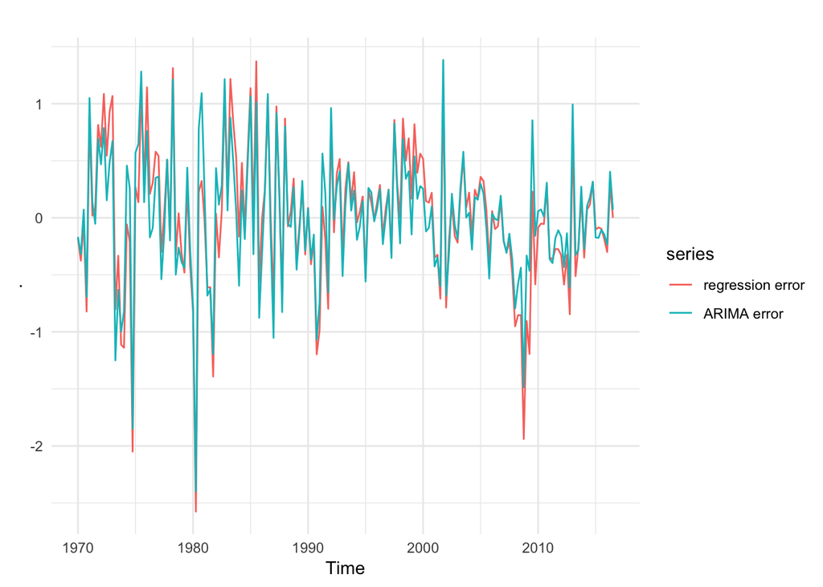

```r
cbind("regression error" = residuals(fit, type = "regression"),
      "ARIMA error" = residuals(fit, type = "innovation")) %>%
  autoplot()
```

It is the ARIMA erros that should resemble a white noise series.

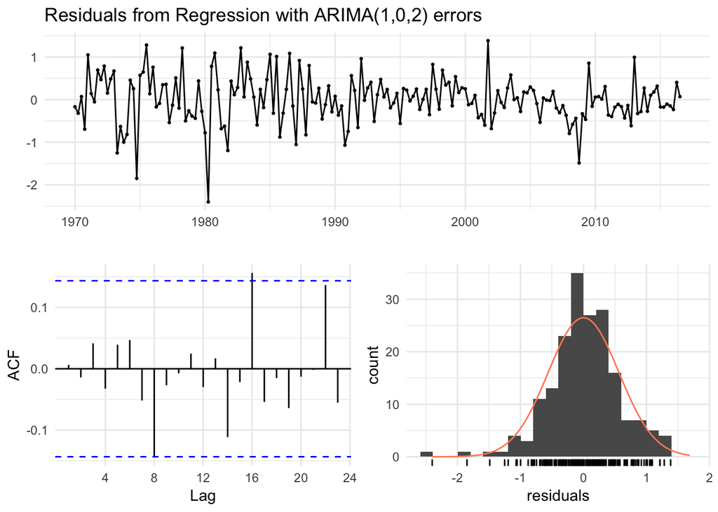

```
##
##  Ljung-Box test
##
## data:  Residuals from Regression with ARIMA(1,0,2) errors
## Q* = 5.8916, df = 3, p-value = 0.117
##
## Model df: 5.   Total lags used: 8
```

```r
checkresiduals(fit)
```

## 9.3 Forecasting

To Forecast using a regression model with ARIMA errors, we need to forecast the regression part of the modela and ARIMA part of the model, and combine the results. As with ordinary regression models in order to obtain forecasts we first need to forecast the preictors. When the predictors are known into the future (e.g.calender-related variables such as time, day of week etc. ) this could be straightforward, but when the predictors are themselves unknown, we must either model them separately, or use assumed future aleus for each predictors.

### Example: US personal consumption and Income

```r
fcast <- forecast(fit, xreg = rep(mean(uschange[, 2]), 8))
```

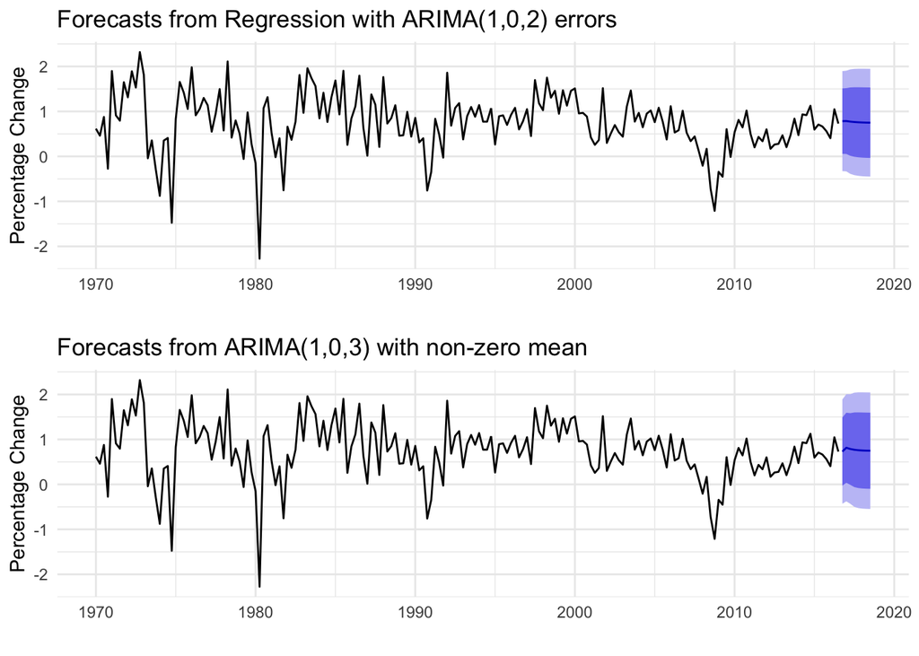

```r
auto_fit <- auto.arima(uschange[, "Consumption"], seasonal = F, allowmean = T)
auto_for <- forecast(auto_fit, h = 8)

x <- autoplot(fcast) +
  labs(x = "", y = "Percentage Change")

y <- autoplot(auto_for) +
  labs(x = "", y = "Percentage Change")

grid.arrange(x,y, ncol = 1)
```

We can see the interval for these two model, the lm + ARIMA moded have a narrow forecast interval than simpel ARIMA model, because we are now able to explain some of the variation in the data using the income predictor

QUESTION: in terms of prediction interval, I still think we need to back test the interval to see does this narrow or wider interval actuall mean anthing. Null hypothesis is, **shorter interal is just accurate as wider interval**, we can use *tscv* to test it maybe.

### Example: Forecasting electricity demand

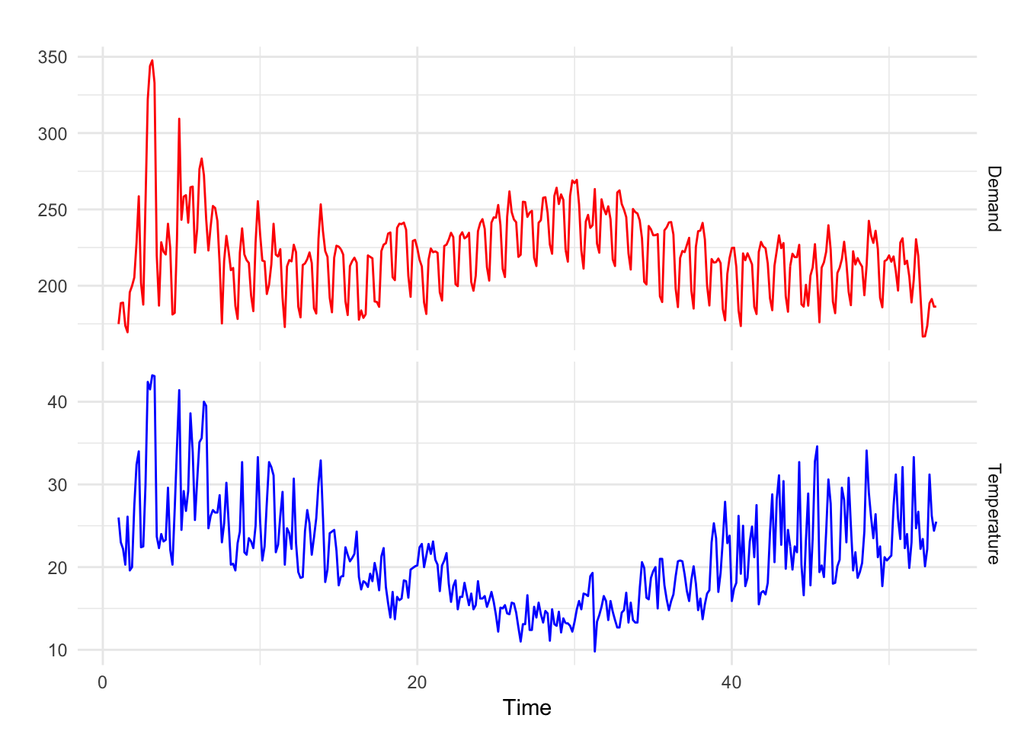

```r
autoplot(elecdaily[, c(1,3)], facets = T, colour = T) +
  scale_color_manual(values = c("red", "blue"))+
  theme(legend.position = "none") +
  labs(y = "")
```

In this case, we fit a quadratic regression model with ARMA erro using auto.arima function

```r
xreg <- cbind(MaxTemp = elecdaily[, "Temperature"],
              MaxTempSq = elecdaily[, "Temperature"]^2,
              Workday = elecdaily[, "WorkDay"])
(fit <- auto.arima(elecdaily[, "Demand"], xreg = xreg))
```

```
## Series: elecdaily[, "Demand"]
## Regression with ARIMA(2,1,2)(2,0,0)[7] errors
##
## Coefficients:
##           ar1     ar2      ma1      ma2    sar1    sar2    drift
##       -0.0622  0.6731  -0.0234  -0.9301  0.2012  0.4021  -0.0191
## s.e.   0.0714  0.0667   0.0413   0.0390  0.0533  0.0567   0.1091
##       xreg.MaxTemp  xreg.MaxTempSq  xreg.Workday
##            -7.4996          0.1789       30.5695
## s.e.        0.4409          0.0084        1.2891
##
## sigma^2 estimated as 43.72:  log likelihood=-1200.7
## AIC=2423.4   AICc=2424.15   BIC=2466.27
```

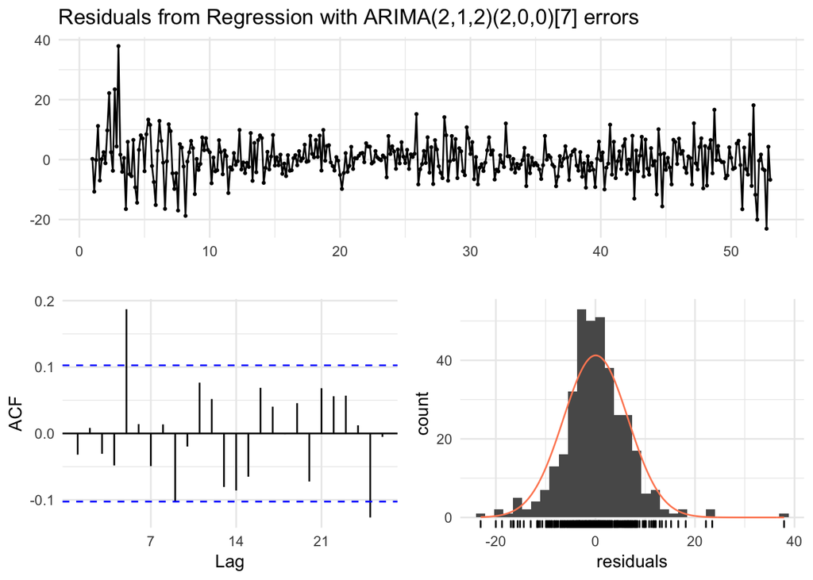

```
##
##  Ljung-Box test
##
## data:  Residuals from Regression with ARIMA(2,1,2)(2,0,0)[7] errors
## Q* = 28.229, df = 4, p-value = 1.121e-05
##
## Model df: 10.   Total lags used: 14
```

```r
checkresiduals(fit)
```

The model have some significant autocorrelation in the residuals, which means the predication interval may not provide accuracy coverage. Also, the histogram of the resduals also show positive outliner, which will also effect the coverage of the prediction intervals.

Using the estiamte model we forecast the next 14 days ahead (a non-week-day being a public holiday for new years day) In this case, we could obtain weather forecast from the weather bureau for the next 14 days.

```r
fcast <- forecast(fit, xreg = cbind(MaxTemp = rep(26, 14),
                                    MaxTempSq = rep(26^2, 14),
                                    Workday = c(0,1,0,0,1,1,1,1,1,0,0,1,1,1)))
```

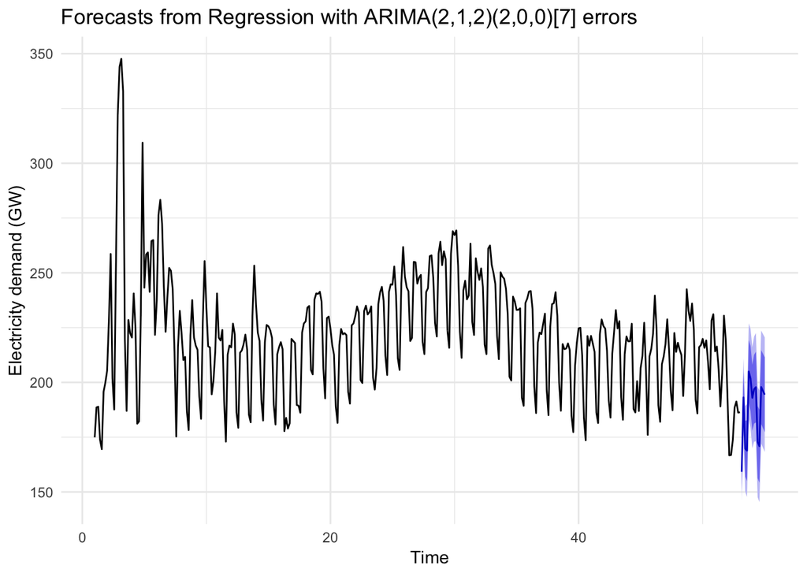

```r
autoplot(fcast) +
  labs(y = "Electricity demand (GW)")
```

The slow down in electricity demand at the end of 2014 has caused the forecasts for the next two weeks to show similarly low demand values.

## 9.4 Stochastic and deterministic trends

Two different way to modelling a *linear trend*.

A deterministic trend is obtained using the regression model.

$y_t = \beta_0 + \beta_1t + \eta_t$ where $\eta_t$ is an ARMA process

A stochastic trend is obtained using the model

$y_t = \beta_0 + \beta_1t +\eta_t$, where $\eta_t$ is an ARIMA process with d = 1. In the latter case, we can difference both sides so that $y_t' = \beta_1 = \eta_t'$, where $\eta_t'$ is an ARMA process. In other words $y_t = y_{t-1} + \beta_1 + \eta_t'$. Where is similar to a random walk with drift, but here the error term is an ARMA process rather than simply white noise.

Althouth these models appear quite similar, their forecasting characterisitics are quite different.

### Example: International visitors to Australia

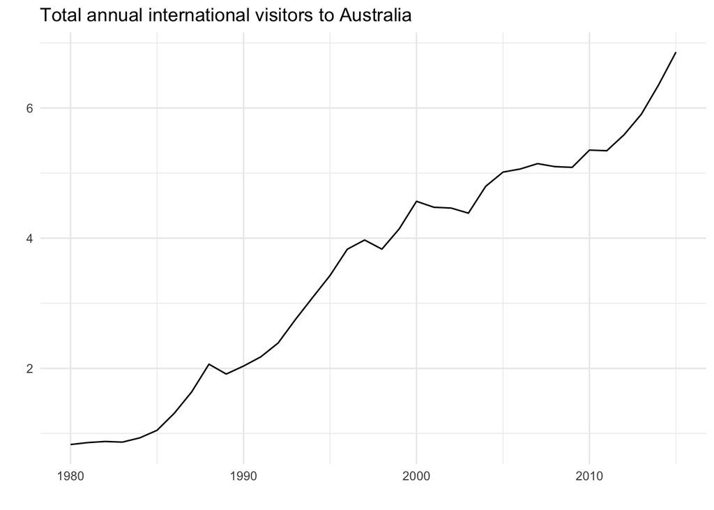

```r
autoplot(austa) +
  labs(x = "", y = "",
       title = "Total annual international visitors to Australia")
```

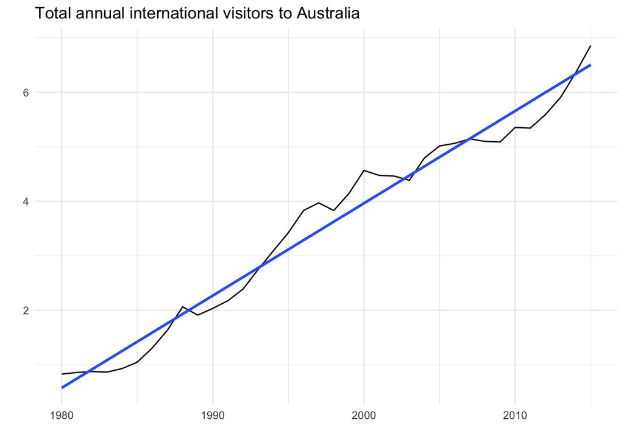

```r
austa %>%
  tk_tbl(rename_index = "Date") %>%
  ggplot(aes(Date, value)) +
  geom_line() +
  geom_smooth(method = "lm", se = F) +
  labs(x = "", y = "",
       title = "Total annual international visitors to Australia")
```

This graphic show the international visitors to Australia from 1980 to 2015. Now we can use both model to model this *linear trend*. After use *lm* model we can see this data basically is linear trend.

Deterministic trend model:

```r
trend <- seq_along(austa)
(fit1 <- auto.arima(austa, d = 0, xreg = trend))
```

```
## Series: austa
## Regression with ARIMA(2,0,0) errors
##
## Coefficients:
##          ar1      ar2  intercept    xreg
##       1.1127  -0.3805     0.4156  0.1710
## s.e.  0.1600   0.1585     0.1897  0.0088
##
## sigma^2 estimated as 0.02979:  log likelihood=13.6
## AIC=-17.2   AICc=-15.2   BIC=-9.28
```

this mdoel can be written as: $y_t = 0.4156 + 0.1710t = \eta_t$

$\eta_t = 1.1127\eta_{t-1} - 0.3805\eta_{t-2} + \epsilon_t$

$\epsilon_t \sim NID(0, 0.02979)$